# IBM EMPLOYEE ATTRITION

2023-07-20

Import all the libraries:

```r
library(tidyverse)
library(caret)
library(tidyverse)
library(caret)
library(ROSE)
library(randomForest)
library(e1071)
library(pROC)
```

```r
library(ggplot2)
library(scales)
library(corrplot)
library(glmnet)
```

Load the data set and Data Preprocessing :

```r
## Load the data set

df = read.csv("IBM HR Data new.csv")
dim(df)
```

```
## [1] 23436    37
```

```r
head(df)
```

```
##   Age             Attrition BusinessTravel DailyRate Department
## 1  41 Voluntary Resignation  Travel_Rarely      1102      Sales
## 2  41 Voluntary Resignation  Travel_Rarely      1102      Sales
## 3  41 Voluntary Resignation  Travel_Rarely      1102      Sales
## 4  41 Voluntary Resignation  Travel_Rarely      1102      Sales
## 5  41 Voluntary Resignation  Travel_Rarely      1102      Sales
## 6  41 Voluntary Resignation  Travel_Rarely      1102      Sales
##   DistanceFromHome Education EducationField EmployeeCount EmployeeNumber
## 1                1         2  Life Sciences             1              1
## 2                1         2  Life Sciences             1              1
## 3                1         2  Life Sciences             1              7
## 4                1         2  Life Sciences             1              8
## 5                1         2  Life Sciences             1              9
## 6                1         2  Life Sciences             1             10
##   Application.ID EnvironmentSatisfaction Gender HourlyRate JobInvolvement
```

[output cut: 48 more lines]

```r
## Rename column names

names(df)[names(df) == "Application ID"] <- "Application_ID"
names(df)[names(df) == "Employee Source"] <- "Employee_Source"

## Remove duplicates

duplicate_rows <- df[duplicated(df$Application_ID), ]

## Print the duplicate rows

print(duplicate_rows) ##### No duplicate rows in the dataset
```

```
##  [1] Age                      Attrition                BusinessTravel
##  [4] DailyRate                Department               DistanceFromHome
##  [7] Education                EducationField           EmployeeCount
## [10] EmployeeNumber           Application.ID           EnvironmentSatisfaction
## [13] Gender                   HourlyRate               JobInvolvement
## [16] JobLevel                 JobRole                  JobSatisfaction
## [19] MaritalStatus            MonthlyIncome            MonthlyRate
## [22] NumCompaniesWorked       Over18                   OverTime
## [25] PercentSalaryHike        PerformanceRating        RelationshipSatisfaction
## [28] StandardHours            StockOptionLevel         TotalWorkingYears
## [31] TrainingTimesLastYear    WorkLifeBalance          YearsAtCompany
## [34] YearsInCurrentRole       YearsSinceLastPromotion  YearsWithCurrManager
## [37] Employee.Source
## <0 rows> (or 0-length row.names)
```

```r
## Dropping unwanted columns

drop_cols=c("Application.ID","EmployeeCount","EmployeeNumber",
            "Employee.Source", "Over18" , "StandardHours")
df[drop_cols]=NULL

## Missing values

df = df[complete.cases(df), ]
summary(df)
```

```
##       Age         Attrition         BusinessTravel       DailyRate
##  Min.   :18.00   Length:23303       Length:23303       Min.   : 102
##  1st Qu.:30.00   Class :character   Class :character   1st Qu.: 465
##  Median :36.00   Mode  :character   Mode  :character   Median : 802
##  Mean   :36.93                                         Mean   : 802
##  3rd Qu.:43.00                                         3rd Qu.:1157
##  Max.   :60.00                                         Max.   :1499
##   Department        DistanceFromHome     Education     EducationField
##  Length:23303       Length:23303       Min.   :1.000   Length:23303
##  Class :character   Class :character   1st Qu.:2.000   Class :character
##  Mode  :character   Mode  :character   Median :3.000   Mode  :character
##                                        Mean   :2.909
##                                        3rd Qu.:4.000
##                                        Max.   :5.000
##  EnvironmentSatisfaction    Gender           HourlyRate        JobInvolvement
##  Min.   :     1.00       Length:23303       Length:23303       Min.   : 1.000
##  1st Qu.:     2.00       Class :character   Class :character   1st Qu.: 2.000
##  Median :     3.00       Mode  :character   Mode  :character   Median : 3.000
##  Mean   :     8.28                                             Mean   : 2.732
##  3rd Qu.:     4.00                                             3rd Qu.: 3.000
##  Max.   :129588.00                                             Max.   :54.000
##     JobLevel       JobRole          JobSatisfaction    MaritalStatus
##  Min.   :1.000   Length:23303       Length:23303       Length:23303
##  1st Qu.:1.000   Class :character   Class :character   Class :character
##  Median :2.000   Mode  :character   Mode  :character   Mode  :character
##  Mean   :2.065
##  3rd Qu.:3.000
##  Max.   :5.000
##  MonthlyIncome       MonthlyRate    NumCompaniesWorked    OverTime
##  Length:23303       Min.   : 2094   Min.   :    0.000   Length:23303
##  Class :character   1st Qu.: 8053   1st Qu.:    1.000   Class :character
##  Mode  :character   Median :14222   Median :    2.000   Mode  :character
##                     Mean   :14304   Mean   :    3.685
##                     3rd Qu.:20460   3rd Qu.:    4.000
##                     Max.   :26999   Max.   :23258.000
##  PercentSalaryHike  PerformanceRating RelationshipSatisfaction
##  Length:23303       Min.   : 3.000    Min.   :1.000
##  Class :character   1st Qu.: 3.000    1st Qu.:2.000
##  Mode  :character   Median : 3.000    Median :3.000
##                     Mean   : 3.156    Mean   :2.713
```

[output cut: 8 more lines]

```
##  Max.   :80.0000   Max.   :40.00     Max.   :30.000        Max.   :4.000
##  YearsAtCompany   YearsInCurrentRole YearsSinceLastPromotion
##  Min.   : 0.000   Min.   : 0.000     Min.   : 0.000
##  1st Qu.: 3.000   1st Qu.: 2.000     1st Qu.: 0.000
##  Median : 5.000   Median : 3.000     Median : 1.000
##  Mean   : 7.015   Mean   : 4.228     Mean   : 2.182
##  3rd Qu.:10.000   3rd Qu.: 7.000     3rd Qu.: 3.000
##  Max.   :40.000   Max.   :18.000     Max.   :15.000
##  YearsWithCurrManager
##  Min.   : 0.00
##  1st Qu.: 2.00
##  Median : 3.00
##  Mean   : 4.13
##  3rd Qu.: 7.00
##  Max.   :17.00
```

```r
## Other pre-processing steps

quantitative_cols <- c("DistanceFromHome", "HourlyRate", "JobSatisfaction",
                          "MonthlyIncome", "PercentSalaryHike")

# Remove rows with string values in specific quantitative columns

clean_df <- df[!rowSums(sapply(df[quantitative_cols], function(x) is.na(as.numeric(x)))), ]
qualitative_cols <- c("Department", "EducationField", "Gender",
                       "JobRole", "MaritalStatus")
clean_df <- clean_df[!rowSums(sapply(clean_df[qualitative_cols], function(x) !is.na(as.numeric(x)))), ]
clean_df = clean_df[complete.cases(clean_df), ]

## Factorized

clean_df$Attrition=factor(clean_df$Attrition,
                          levels = c("Voluntary Resignation","Current employee"),
                          labels = c("Voluntary_Resignation","Current_employee"))

cols=c("BusinessTravel","Department","Education","EducationField","EnvironmentSatisfaction",
       "Gender","JobLevel","JobRole","JobSatisfaction","MaritalStatus", "JobInvolvement",
       "OverTime","PerformanceRating","RelationshipSatisfaction","StockOptionLevel",
       "WorkLifeBalance")

clean_df[cols] <- lapply(clean_df[cols], factor)

clean_df$HourlyRate <- as.numeric(clean_df$HourlyRate)
clean_df$MonthlyIncome <- as.numeric(clean_df$MonthlyIncome)
clean_df$DistanceFromHome <- as.numeric(clean_df$DistanceFromHome)
clean_df$PercentSalaryHike <- as.numeric(clean_df$PercentSalaryHike)
clean_df[clean_df == ""] <- NA
clean_df <- na.omit(clean_df)

## Divide the data set into training and testing

prop <- clean_df %>% select(Attrition) %>% group_by(Attrition) %>% summarize(n=n()) %>%
  mutate(pct=round(prop.table(n), 2))

set.seed(111)
trainIndex <- createDataPartition(clean_df$Attrition, p=0.8,
                                  list=FALSE, times=1)
train.data <- clean_df[trainIndex,]
test.data<- clean_df[-trainIndex,]

dim(train.data)
```

```
## [1] 18580    31
```

```r
dim(test.data)
```

```
## [1] 4644   31
```

Exploratory Data Analysis :

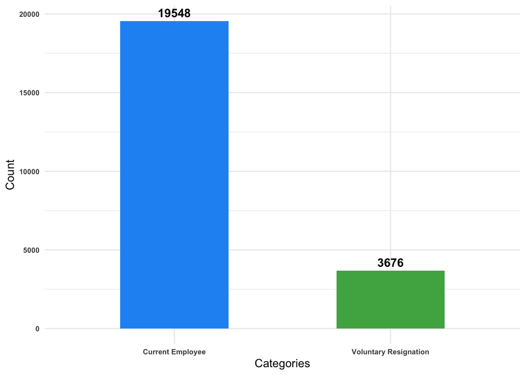

```r
data1 = clean_df
data1$Attrition<-factor(data1$Attrition,
                         levels = c("Voluntary_Resignation","Current_employee"),
                         labels = c("Voluntary Resignation","Current Employee"))
data1$Education = factor(data1$Education,
                          levels = c(1,2,3,4,5),
                          labels = c('Below College', 'College','Bachelor'
                                     ,'Master','Doctor'))
data1$EnvironmentSatisfaction=factor(data1$EnvironmentSatisfaction,
                                      levels = c(1,2,3,4),
                                      labels=c('low','Medium','High','Very High'))

cols=c("Education","Department","EnvironmentSatisfaction")
data1[cols] <- lapply(data1[cols], factor)

## Attrition

counts <- table(data1$Attrition)
df <- data.frame(categories = names(counts), count = as.numeric(counts))

ggplot(data = df, aes(x = categories, y = count, fill = categories)) +
  geom_bar(stat = "identity", width = 0.5) +
  geom_text(aes(label = count), vjust = -0.5, fontface = "bold", size = 4) +
  labs(x = "Categories", y = "Count") +
  scale_fill_manual(values = c("#2196F3", "#4CAF50")) +
  theme_minimal() +
  theme(plot.title = element_text(size = 9, face = "bold"),
        axis.text = element_text(size = 7, face = "bold"),
        legend.position = "none")
```

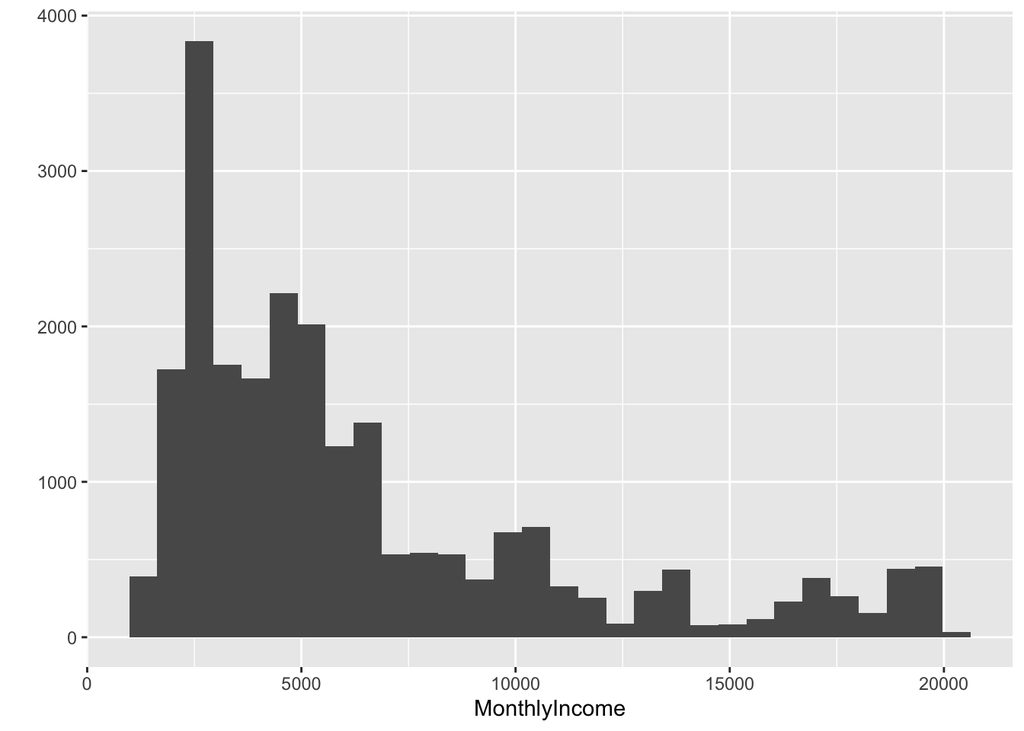

```r
## Monthly Income

qplot(MonthlyIncome,data = data1,geom = "histogram")
```

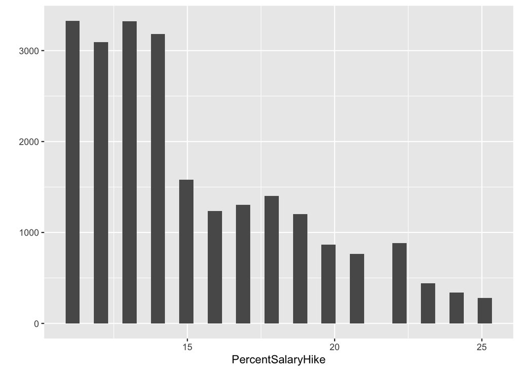

```r
## Percent Salary Hike

qplot(PercentSalaryHike,data = data1,geom = "histogram")
```

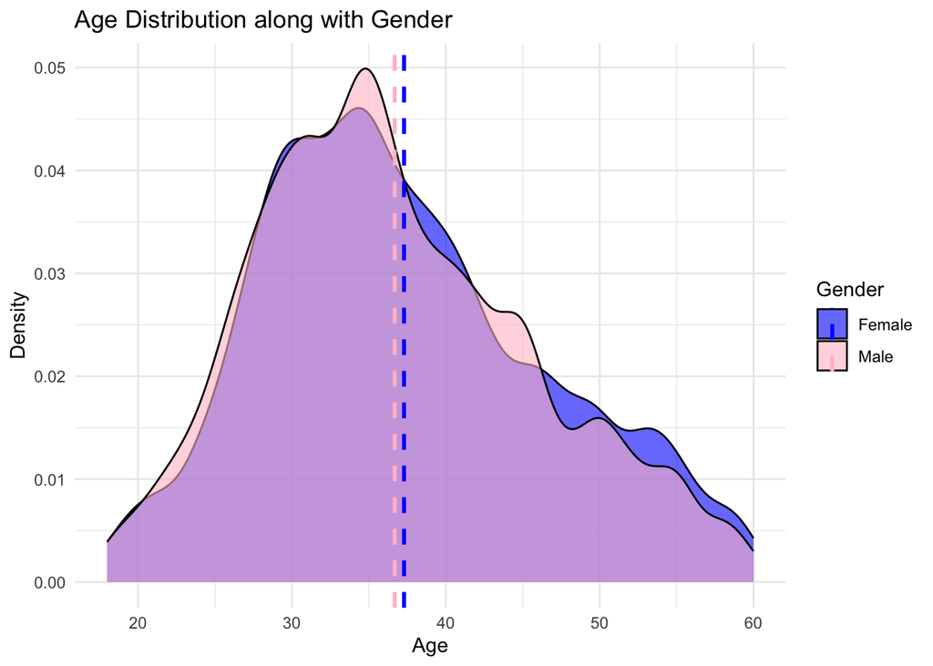

```r
## Age vs Gender

mean_data <- aggregate(Age ~ Gender, data1, mean)
ggplot(data1, aes(x = Age, fill = Gender)) +
  geom_density(alpha = 0.6) +
  geom_vline(data = mean_data, aes(xintercept = Age, color = Gender),
             linetype = "dashed", size = 1) +
  labs(title = "Age Distribution along with Gender", x = "Age", y = "Density") +
  scale_fill_manual(values = c("blue", "pink")) +
  scale_color_manual(values = c("blue", "pink")) +
  theme_minimal()
```

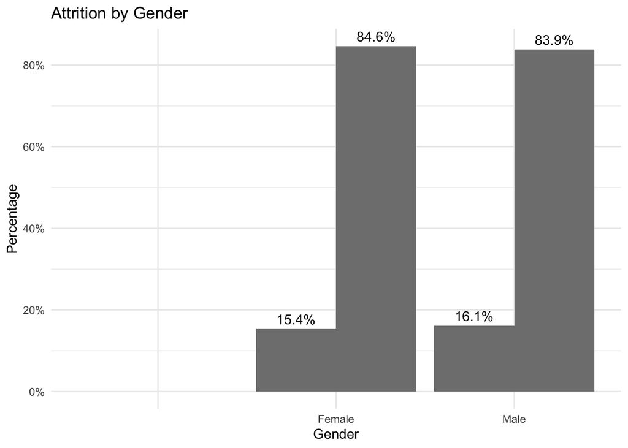

```r
## Gender vs Attrition

percentage_data <- with(data1, prop.table(table(Gender, Attrition), 1) * 100)
percentage_df <- as.data.frame(percentage_data)
ggplot(percentage_df, aes(x = Gender, y = Freq, fill = Attrition)) +
  geom_bar(stat = "identity", position = "dodge") +
  geom_text(aes(label = sprintf("%.1f%%", Freq)), position = position_dodge(width = 0.9), vjust = -0.5) +
  labs(title = "Attrition by Gender",
       x = "Gender", y = "Percentage",
       fill = "Attrition") +
  scale_fill_manual(values = c("Yes" = "red", "No" = "blue")) +
  scale_y_continuous(labels = percent_format(scale = 1)) +
  theme_minimal()
```

```r
## Dep, ENV sat, Gender

data1=read.csv("cleaned_data.csv")
data1$Attrition<-factor(data1$Attrition,
                        levels = c("Voluntary_Resignation","Current_employee"),
                        labels = c("Voluntary Resignation","Current Employee"))
data1$EnvironmentSatisfaction <- as.numeric(data1$EnvironmentSatisfaction)
averaged_data <- data1 %>%
  group_by(Department, Gender) %>%
  summarize(Average_Value = mean(EnvironmentSatisfaction))
```

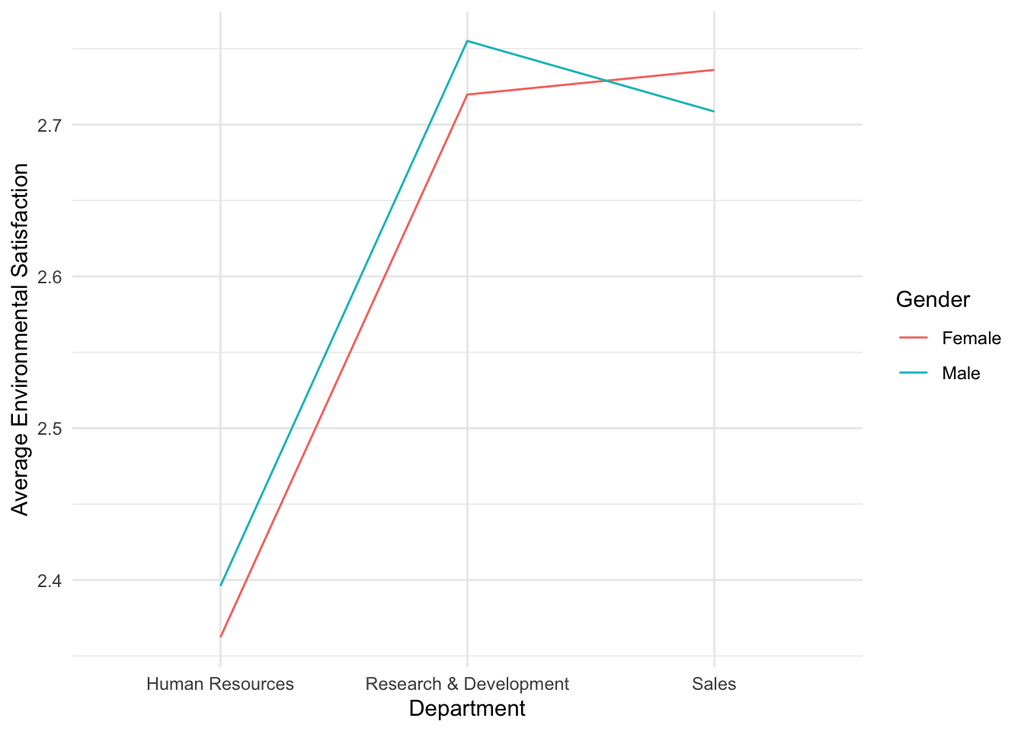

```r
ggplot(averaged_data, aes(x = Department, y = Average_Value, group = Gender, color = Gender)) +
  geom_line() +
  labs(x = "Department", y = "Average Environmental Satisfaction",
       color = "Gender") +
  theme_minimal()
```

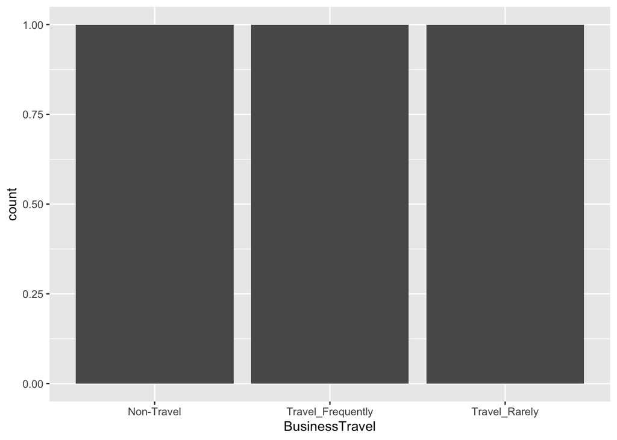

```r
## Business Travel vs Environment Satisfaction

ggplot(data1, aes(fill = EnvironmentSatisfaction, x = BusinessTravel)) +
  geom_bar(position = "fill")
```

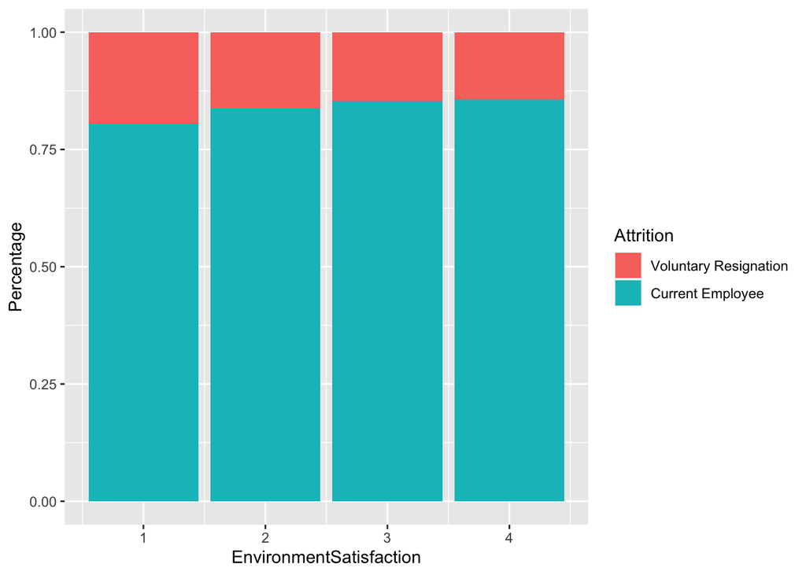

```r
## Attrition vs Environment Satisfaction

ggplot(data1, aes(fill = Attrition, x = EnvironmentSatisfaction)) +
  geom_bar(position = "fill") + labs(y = "Percentage")
```

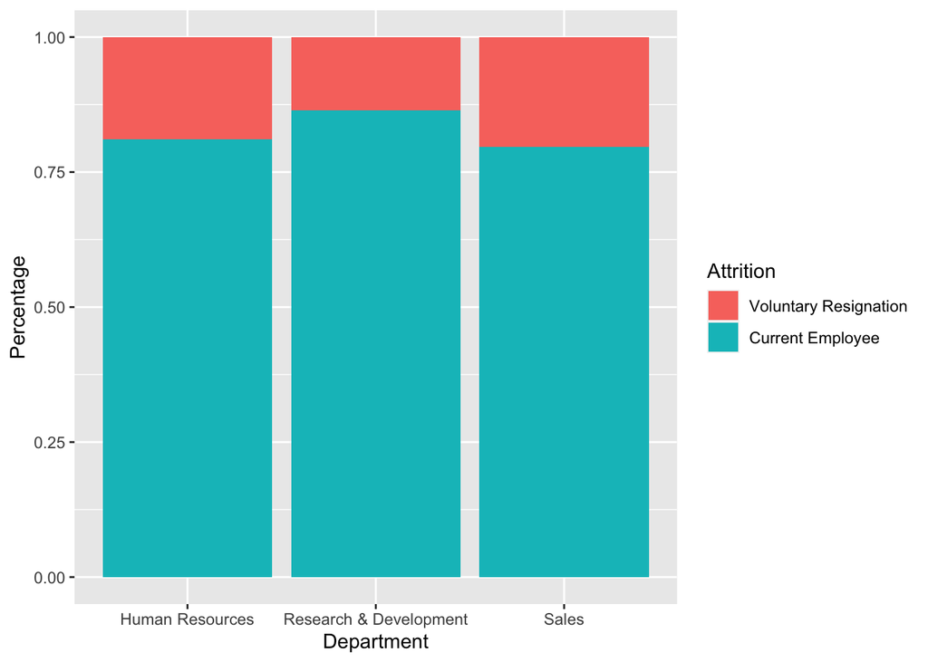

```r
## Attrition vs Department

ggplot(data1, aes(fill = Attrition, x = Department)) +
  geom_bar(position = "fill") + labs(y = "Percentage")
```

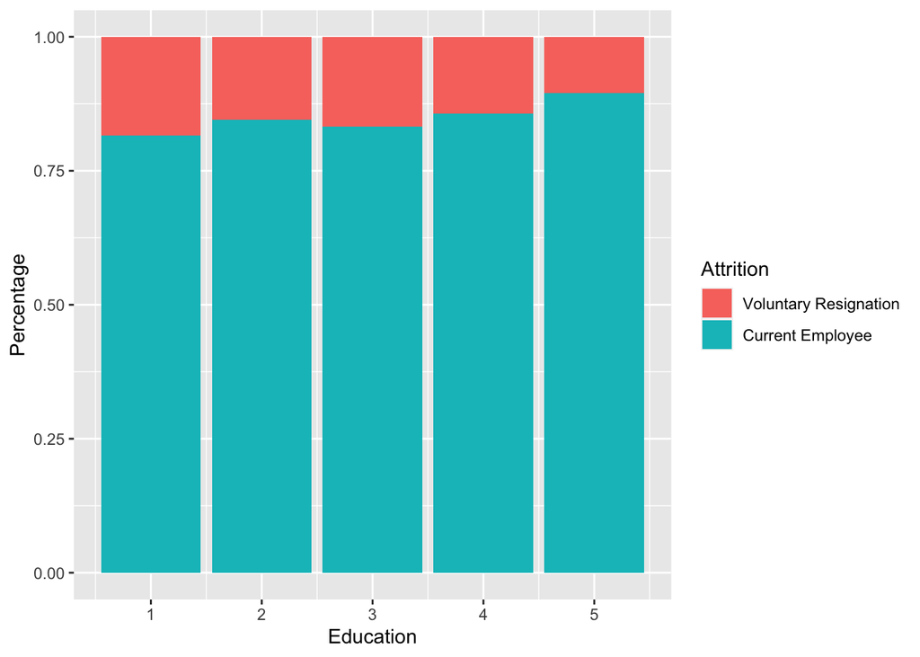

```r
## Attrition vs Education

ggplot(data1, aes(fill = Attrition, x = Education)) +
  geom_bar(position = "fill") + labs(y = "Percentage")
```

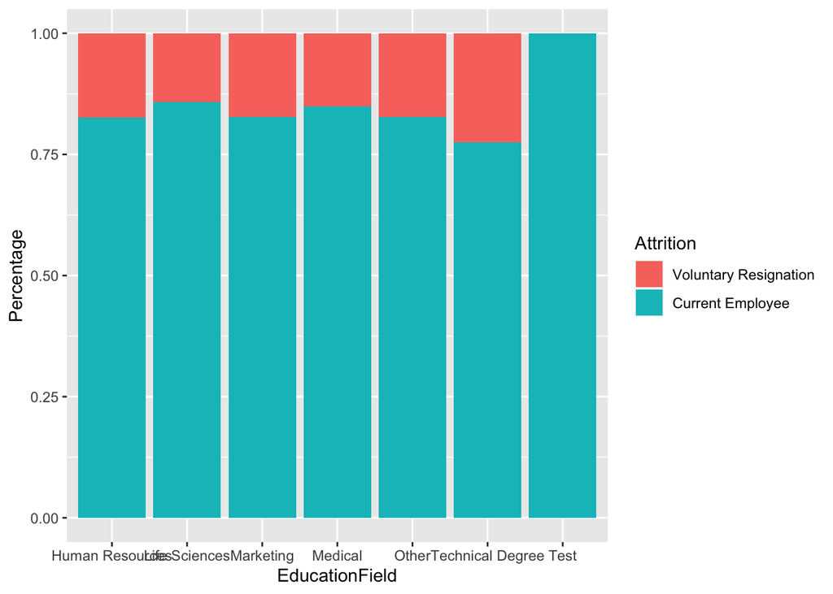

```r
## Attrition vs Education Field

ggplot(data1, aes(fill = Attrition, x = EducationField)) +
  geom_bar(position = "fill") + labs(y = "Percentage")
```

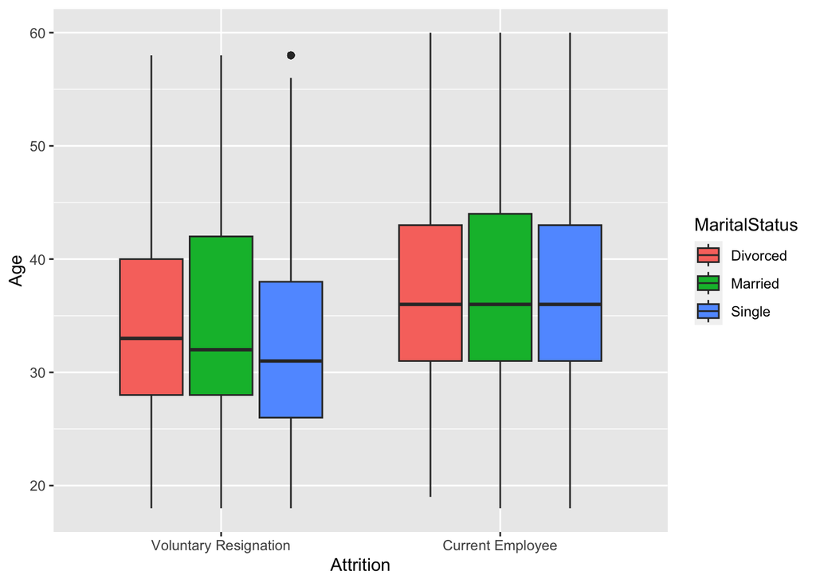

```r
## Attrition vs Marital Status

data1$Attrition=as.factor(data1$Attrition)
data1$MaritalStatus=as.factor(data1$MaritalStatus)
p8=ggplot(data = data1,aes(x=Attrition,y=Age,fill=MaritalStatus))+geom_boxplot()+scale_x_discrete(labels=c("1"="Voluntary Resign","2"="Current Employees"))
p8
```

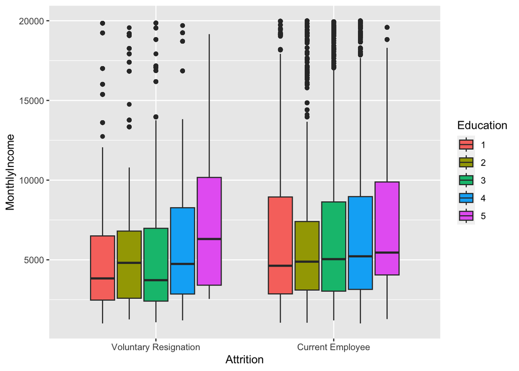

```r
## Education, Monthly Income vs Attrition

data1$Attrition=as.factor(data1$Attrition)
data1$Education=as.factor(data1$Education)
p7=ggplot(data = data1,aes(x=Attrition,y=MonthlyIncome,fill=Education))+geom_boxplot()+scale_x_discrete(labels=c("1"="Voluntary Resign","2"="Current Employees"))
p7
```

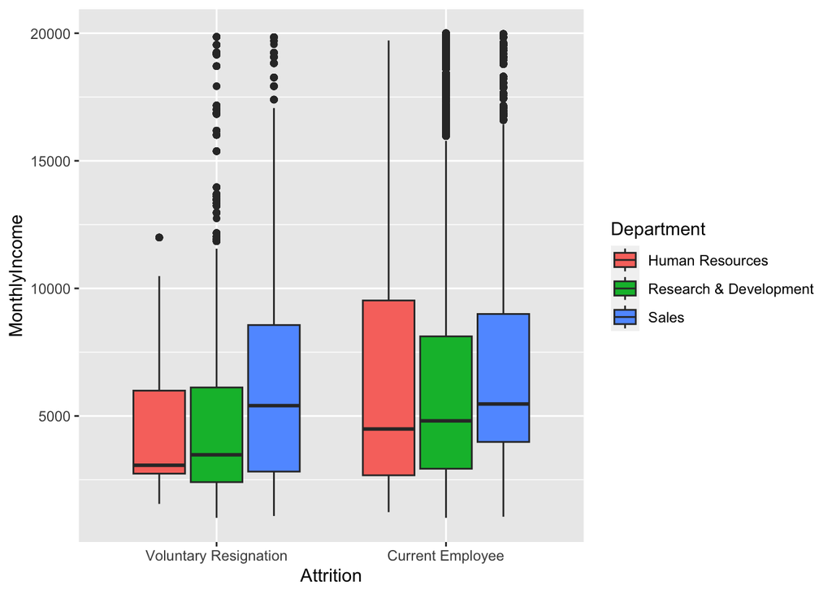

```r
## Department, Monthly Income vs Attrition

data1$Attrition=as.factor(data1$Attrition)
data1$Education=as.factor(data1$Department)
p7=ggplot(data = data1,aes(x=Attrition,y=MonthlyIncome,fill=Department))+geom_boxplot()+scale_x_discrete(labels=c("1"="Voluntary Resign","2"="Current Employees"))
p7
```

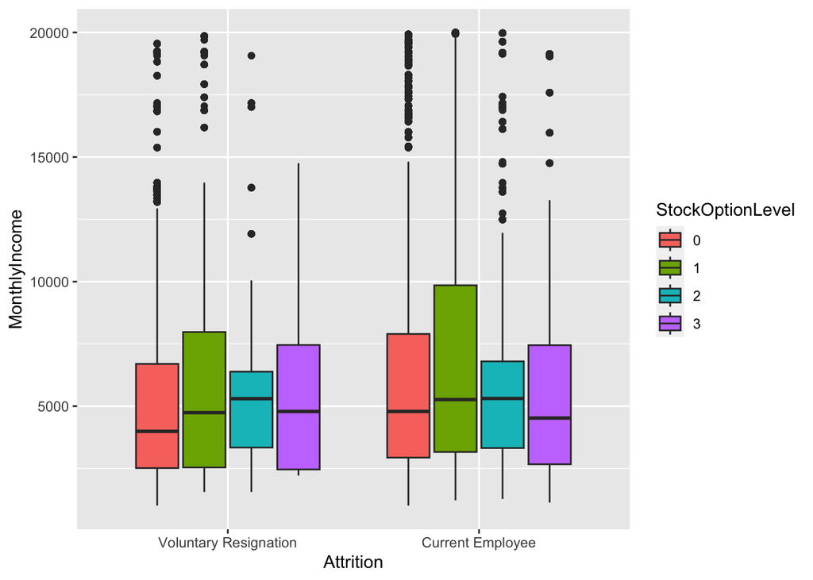

```r
## StockOptionLevel, Monthly Income vs Attrition

data1$Attrition=as.factor(data1$Attrition)
data1$StockOptionLevel=as.factor(data1$StockOptionLevel)
p9=ggplot(data = data1,aes(x=Attrition,y=MonthlyIncome,fill=StockOptionLevel))+geom_boxplot()+scale_x_discrete(labels=c("1"="Voluntary Resign","2"="Current Employees"))
p9
```

Check for multicolinearity

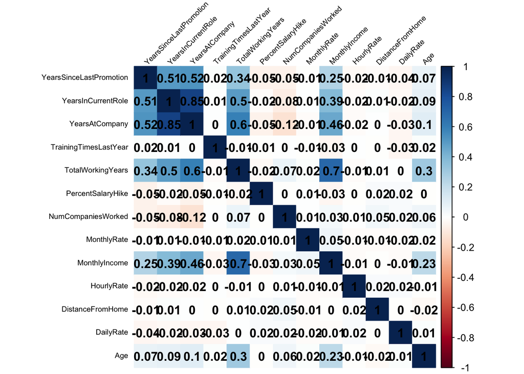

```r
cor_columns <- c("YearsSinceLastPromotion","YearsInCurrentRole","YearsAtCompany",
                 "TrainingTimesLastYear", "TotalWorkingYears","PercentSalaryHike",
                 "NumCompaniesWorked","MonthlyRate","MonthlyIncome",
                 "HourlyRate","DistanceFromHome","DailyRate","Age")

cor_cot <- train.data %>% select(all_of(cor_columns))
cor_matrix <- cor(cor_cot, method = "spearman")

corrplot(cor_matrix, method = "color", addCoef.col = "black", tl.col = "black",
         tl.cex = 0.6, tl.srt = 45)
```

In this context, we observe the presence of multicollinearity among variables. To address this issue, we can opt for ridge and lasso regression as alternatives to logistic regression. These regularization techniques help mitigate the impact of multicollinearity and provide more robust model estimates. Instead of logistic model, we can fit ridge, lasso and e-net regression models.

Statistical Models:

```r
data1=train.data
data2=test.data

cols <- c("BusinessTravel","Department","Education","EducationField","EnvironmentSatisfaction",
          "Gender","JobLevel","JobRole","JobSatisfaction","MaritalStatus", "JobInvolvement",
          "OverTime","PerformanceRating","RelationshipSatisfaction","StockOptionLevel",
          "WorkLifeBalance")

for (col in cols) {
  data1[[col]] <- as.integer(factor(data1[[col]], levels = unique(data1[[col]])))
  data2[[col]] <- as.integer(factor(data2[[col]], levels = unique(data2[[col]])))
}

data1[cols] <- lapply(data1[cols], factor)
data2[cols] <- lapply(data2[cols], factor)

data1$Attrition<-factor(data1$Attrition,
                        levels = c('Voluntary_Resignation','Current_employee'),
                        labels = c(0,1))

data2$Attrition<-factor(data2$Attrition,
                        levels = c('Voluntary_Resignation','Current_employee'),
                        labels = c(0,1))

# Remove level 1 from 'EducationField'
data2$EducationField <- droplevels(data2$EducationField, exclude = "7")
data2 <- na.omit(data2)

x=model.matrix(Attrition ~.,data = data1)[,-1]
y=data1$Attrition

####################################################################################
#            ridge                                                                 #
####################################################################################

#cross validation to select best lambda
lambda<-10^seq(-3,3,length=100)
set.seed(111)

ridge.model<-train(
  x = x,
  y = y,
  method = "glmnet",
  preProc = c("zv", "center", "scale"),
  trControl = trainControl(method = "cv", number = 10),
  tuneLength = 10,
  family="binomial",
  tuneGrid = expand.grid(alpha = 0, lambda = lambda))


# Make predictions on the test data
x.test <- model.matrix(Attrition ~., data2)[,-1]
probabilities <- predict(ridge.model,x.test, type = "raw")
probabilities<-ordered(probabilities, levels=c("0","1"))

# Model accuracy
confusionMatrix(table(probabilities,data2$Attrition))
```

```
## Confusion Matrix and Statistics
##
##
## probabilities    0    1
##             0   60   45
##             1  675 3863
##
##                Accuracy : 0.8449
##                  95% CI : (0.8342, 0.8552)
##     No Information Rate : 0.8417
##     P-Value [Acc > NIR] : 0.281
##
##                   Kappa : 0.1075
##
##  Mcnemar's Test P-Value : <2e-16
##
##             Sensitivity : 0.08163
##             Specificity : 0.98849
##          Pos Pred Value : 0.57143
##          Neg Pred Value : 0.85126
##              Prevalence : 0.15830
##          Detection Rate : 0.01292
##    Detection Prevalence : 0.02261
##       Balanced Accuracy : 0.53506
##
##        'Positive' Class : 0
##
```

```r
####################################################################################
#                  lasso                                                           #
####################################################################################

#cross validation to select best lambda
lambda<-10^seq(-3,3,length=100)

set.seed(111)
lasso.model<-train(
  x = x,
  y = y,
  method = "glmnet",
  preProc = c("zv", "center", "scale"),
  trControl = trainControl(method = "cv", number = 10),
  tuneLength = 10,
  family="binomial",
  tuneGrid = expand.grid(alpha = 1, lambda = lambda)

)


# Make predictions on the test data
x.test <- model.matrix(Attrition ~., data2)[,-1]
probabilities <- predict(lasso.model,x.test, type = "raw")
probabilities<-ordered(probabilities, levels=c("0","1"))

# Model accuracy
confusionMatrix(table(probabilities,data2$Attrition))
```

```
## Confusion Matrix and Statistics
##
##
## probabilities    0    1
##             0   58   44
##             1  677 3864
##
##                Accuracy : 0.8447
##                  95% CI : (0.834, 0.855)
##     No Information Rate : 0.8417
##     P-Value [Acc > NIR] : 0.2948
##
##                   Kappa : 0.104
##
##  Mcnemar's Test P-Value : <2e-16
##
##             Sensitivity : 0.07891
##             Specificity : 0.98874
##          Pos Pred Value : 0.56863
##          Neg Pred Value : 0.85091
##              Prevalence : 0.15830
##          Detection Rate : 0.01249
##    Detection Prevalence : 0.02197
##       Balanced Accuracy : 0.53383
##
##        'Positive' Class : 0
##
```

```r
###################################################################################
#                 elastic-net                                                     #
###################################################################################


# for reproducibility
set.seed(111)

# grid search across
elastic.model <- train(
  x = x,
  y = y,
  method = "glmnet",
  preProc = c("zv", "center", "scale"),
  trControl = trainControl(method = "cv", number = 10),
  tuneLength = 10,
  family="binomial"
)


# Make predictions on the test data
probabilities <- predict(elastic.model,x.test, type = "raw")
probabilities<-ordered(probabilities, levels=c("0","1"))

# Model accuracy
confusionMatrix(table(probabilities,data2$Attrition))
```

```
## Confusion Matrix and Statistics
##
##
## probabilities    0    1
##             0   69   72
##             1  666 3836
##
##                Accuracy : 0.8411
##                  95% CI : (0.8302, 0.8515)
##     No Information Rate : 0.8417
##     P-Value [Acc > NIR] : 0.5577
##
##                   Kappa : 0.1123
##
##  Mcnemar's Test P-Value : <2e-16
##
##             Sensitivity : 0.09388
##             Specificity : 0.98158
##          Pos Pred Value : 0.48936
##          Neg Pred Value : 0.85207
##              Prevalence : 0.15830
##          Detection Rate : 0.01486
##    Detection Prevalence : 0.03037
##       Balanced Accuracy : 0.53773
##
##        'Positive' Class : 0
##
```

During the exploratory data analysis (EDA), we observed that the response variable is not balanced, which may be contributing to the lower sensitivity To address this class imbalance issue and improve the model’s performance, we can apply various sampling techniques. Here are three common approaches:

1. **Over-sampling**: Over-sampling involves increasing the number of instances of the minority class (less frequent class) by generating synthetic samples. This can be done using techniques like duplication, bootstrapping, or the Synthetic Minority Over-sampling Technique (SMOTE).
2. **Under-sampling**: Under-sampling, on the other hand, involves reducing the number of instances of the majority class (more frequent class) to achieve a balanced dataset. This can be done randomly or using specific techniques like the Tomek links method.
3. **Synthetic-sampling**: Synthetic sampling generates new instances of the minority class by creating synthetic examples based on the existing data. The most common method for synthetic sampling is SMOTE, which creates synthetic samples by interpolating between existing minority class samples.

1. Over-sampling

```r
#Oversampling

data_balanced_over <- ovun.sample(Attrition ~ ., data = data1, method = "over",N = 30968,seed = 1)$data
x=model.matrix(Attrition~.,data_balanced_over)[,-1]
y=data_balanced_over$Attrition

####################################################################################
#            ridge                                                                 #
####################################################################################

#cross validation to select best lambda
lambda<-10^seq(-3,3,length=100)
set.seed(111)

ridge.model<-train(
  x = x,
  y = y,
  method = "glmnet",
  preProc = c("zv", "center", "scale"),
  trControl = trainControl(method = "cv", number = 10),
  tuneLength = 10,
  family="binomial",
  tuneGrid = expand.grid(alpha = 0, lambda = lambda))


# Make predictions on the test data
x.test <- model.matrix(Attrition ~., data2)[,-1]
probabilities <- predict(ridge.model,x.test, type = "raw")
probabilities<-ordered(probabilities, levels=c("0","1"))
observed.classes=data2$Attrition

# Model accuracy
confusionMatrix(table(probabilities,observed.classes))
```

```
## Confusion Matrix and Statistics
##
##              observed.classes
## probabilities    0    1
##             0  495 1265
##             1  240 2643
##
##                Accuracy : 0.6759
##                  95% CI : (0.6622, 0.6893)
##     No Information Rate : 0.8417
##     P-Value [Acc > NIR] : 1
##
##                   Kappa : 0.2233
##
##  Mcnemar's Test P-Value : <2e-16
##
##             Sensitivity : 0.6735
##             Specificity : 0.6763
##          Pos Pred Value : 0.2812
##          Neg Pred Value : 0.9168
##              Prevalence : 0.1583
##          Detection Rate : 0.1066
##    Detection Prevalence : 0.3791
##       Balanced Accuracy : 0.6749
##
##        'Positive' Class : 0
##
```

```r
####################################################################################
#                  lasso                                                           #
####################################################################################
#cross validation to select best lambda
lambda<-10^seq(-3,3,length=100)

set.seed(111)
lasso.model<-train(
  x = x,
  y = y,
  method = "glmnet",
  preProc = c("zv", "center", "scale"),
  trControl = trainControl(method = "cv", number = 10),
  tuneLength = 10,
  family="binomial",
  tuneGrid = expand.grid(alpha = 1, lambda = lambda)

)


# Make predictions on the test data
x.test <- model.matrix(Attrition ~., data2)[,-1]
probabilities <- predict(lasso.model,x.test, type = "raw")
probabilities<-ordered(probabilities, levels=c("0","1"))

# Model accuracy
confusionMatrix(table(probabilities,observed.classes))
```

```
## Confusion Matrix and Statistics
##
##              observed.classes
## probabilities    0    1
##             0  488 1236
##             1  247 2672
##
##                Accuracy : 0.6806
##                  95% CI : (0.667, 0.694)
##     No Information Rate : 0.8417
##     P-Value [Acc > NIR] : 1
##
##                   Kappa : 0.2248
##
##  Mcnemar's Test P-Value : <2e-16
##
##             Sensitivity : 0.6639
##             Specificity : 0.6837
##          Pos Pred Value : 0.2831
##          Neg Pred Value : 0.9154
##              Prevalence : 0.1583
##          Detection Rate : 0.1051
##    Detection Prevalence : 0.3713
##       Balanced Accuracy : 0.6738
##
##        'Positive' Class : 0
##
```

```r
###################################################################################
#                 elastic-net                                                     #
###################################################################################


# for reproducibility
set.seed(111)

# grid search across
elastic.model <- train(
  x = x,
  y = y,
  method = "glmnet",
  preProc = c("zv", "center", "scale"),
  trControl = trainControl(method = "cv", number = 10),
  tuneLength = 10,
  family="binomial"
)


# Make predictions on the test data
probabilities <- predict(elastic.model,x.test, type = "raw")
probabilities<-ordered(probabilities, levels=c("0","1"))


# Model accuracy
confusionMatrix(table(probabilities,observed.classes))
```

```
## Confusion Matrix and Statistics
##
##              observed.classes
## probabilities    0    1
##             0  487 1236
##             1  248 2672
##
##                Accuracy : 0.6804
##                  95% CI : (0.6667, 0.6938)
##     No Information Rate : 0.8417
##     P-Value [Acc > NIR] : 1
##
##                   Kappa : 0.224
##
##  Mcnemar's Test P-Value : <2e-16
##
##             Sensitivity : 0.6626
##             Specificity : 0.6837
##          Pos Pred Value : 0.2826
##          Neg Pred Value : 0.9151
##              Prevalence : 0.1583
##          Detection Rate : 0.1049
##    Detection Prevalence : 0.3711
##       Balanced Accuracy : 0.6732
##
##        'Positive' Class : 0
##
```

2. Under-sampling

```r
#Undersampling

data_balanced_under <- ovun.sample(Attrition ~ ., data = data1, method = "under",N =5756 , seed = 1)$data
x=model.matrix(Attrition~.,data_balanced_under)[,-1]
y=data_balanced_under$Attrition


####################################################################################
#            ridge                                                                 #
####################################################################################

#cross validation to select best lambda
lambda<-10^seq(-3,3,length=100)
set.seed(111)

ridge.model<-train(
  x = x,
  y = y,
  method = "glmnet",
  preProc = c("zv", "center", "scale"),
  trControl = trainControl(method = "cv", number = 10),
  tuneLength = 10,
  family="binomial",
  tuneGrid = expand.grid(alpha = 0, lambda = lambda))


# Make predictions on the test data
x.test <- model.matrix(Attrition ~., data2)[,-1]
probabilities <- predict(ridge.model,x.test, type = "raw")
probabilities<-ordered(probabilities, levels=c("0","1"))
observed.classes=data2$Attrition

# Model accuracy
confusionMatrix(table(probabilities,observed.classes))
```

```
## Confusion Matrix and Statistics
##
##              observed.classes
## probabilities    0    1
##             0  535 1544
##             1  200 2364
##
##                Accuracy : 0.6244
##                  95% CI : (0.6103, 0.6383)
##     No Information Rate : 0.8417
##     P-Value [Acc > NIR] : 1
##
##                   Kappa : 0.191
##
##  Mcnemar's Test P-Value : <2e-16
##
##             Sensitivity : 0.7279
##             Specificity : 0.6049
##          Pos Pred Value : 0.2573
##          Neg Pred Value : 0.9220
##              Prevalence : 0.1583
##          Detection Rate : 0.1152
##    Detection Prevalence : 0.4478
##       Balanced Accuracy : 0.6664
##
##        'Positive' Class : 0
##
```

```r
####################################################################################
#                  lasso                                                           #
####################################################################################
#cross validation to select best lambda
lambda<-10^seq(-3,3,length=100)

set.seed(111)
lasso.model<-train(
  x = x,
  y = y,
  method = "glmnet",
  preProc = c("zv", "center", "scale"),
  trControl = trainControl(method = "cv", number = 10),
  tuneLength = 10,
  family="binomial",
  tuneGrid = expand.grid(alpha = 1, lambda = lambda)

)


# Make predictions on the test data
x.test <- model.matrix(Attrition ~., data2)[,-1]
probabilities <- predict(lasso.model,x.test, type = "raw")
probabilities<-ordered(probabilities, levels=c("0","1"))

# Model accuracy
confusionMatrix(table(probabilities,data2$Attrition))
```

```
## Confusion Matrix and Statistics
##
##
## probabilities    0    1
##             0  528 1466
##             1  207 2442
##
##                Accuracy : 0.6397
##                  95% CI : (0.6257, 0.6535)
##     No Information Rate : 0.8417
##     P-Value [Acc > NIR] : 1
##
##                   Kappa : 0.2025
##
##  Mcnemar's Test P-Value : <2e-16
##
##             Sensitivity : 0.7184
##             Specificity : 0.6249
##          Pos Pred Value : 0.2648
##          Neg Pred Value : 0.9219
##              Prevalence : 0.1583
##          Detection Rate : 0.1137
##    Detection Prevalence : 0.4295
##       Balanced Accuracy : 0.6716
##
##        'Positive' Class : 0
##
```

```r
###################################################################################
#                 elastic-net                                                     #
###################################################################################


# for reproducibility
set.seed(111)

# grid search across
elastic.model <- train(
  x = x,
  y = y,
  method = "glmnet",
  preProc = c("zv", "center", "scale"),
  trControl = trainControl(method = "cv", number = 10),
  tuneLength = 10,
  family="binomial"
)


# Make predictions on the test data
probabilities <- predict(elastic.model,x.test, type = "raw")
probabilities<-ordered(probabilities, levels=c("0","1"))

# Model accuracy
confusionMatrix(table(probabilities,data2$Attrition))
```

```
## Confusion Matrix and Statistics
##
##
## probabilities    0    1
##             0  544 1575
##             1  191 2333
##
##                Accuracy : 0.6196
##                  95% CI : (0.6055, 0.6336)
##     No Information Rate : 0.8417
##     P-Value [Acc > NIR] : 1
##
##                   Kappa : 0.1911
##
##  Mcnemar's Test P-Value : <2e-16
##
##             Sensitivity : 0.7401
##             Specificity : 0.5970
##          Pos Pred Value : 0.2567
##          Neg Pred Value : 0.9243
##              Prevalence : 0.1583
##          Detection Rate : 0.1172
##    Detection Prevalence : 0.4564
##       Balanced Accuracy : 0.6686
##
##        'Positive' Class : 0
##
```

3. Synthetic sampling

```r
#synthatic sampling
data.rose <- ROSE(Attrition ~ ., data = data1, seed = 1)$data
x=model.matrix(Attrition~.,data.rose)[,-1]
y=data.rose$Attrition

####################################################################################
#            ridge                                                                 #
####################################################################################

#cross validation to select best lambda
lambda<-10^seq(-3,3,length=100)
set.seed(111)

ridge.model<-train(
  x = x,
  y = y,
  method = "glmnet",
  preProc = c("zv", "center", "scale"),
  trControl = trainControl(method = "cv", number = 10),
  tuneLength = 10,
  family="binomial",
  tuneGrid = expand.grid(alpha = 0, lambda = lambda))

# Make predictions on the test data
x.test <- model.matrix(Attrition ~., data2)[,-1]
probabilities <- predict(ridge.model,x.test, type = "raw")
probabilities<-ordered(probabilities, levels=c("0","1"))
observed.classes=data2$Attrition

# Model accuracy
confusionMatrix(table(probabilities,observed.classes))
```

```
## Confusion Matrix and Statistics
##
##              observed.classes
## probabilities    0    1
##             0  500 1334
##             1  235 2574
##
##                Accuracy : 0.6621
##                  95% CI : (0.6483, 0.6757)
##     No Information Rate : 0.8417
##     P-Value [Acc > NIR] : 1
##
##                   Kappa : 0.2109
##
##  Mcnemar's Test P-Value : <2e-16
##
##             Sensitivity : 0.6803
##             Specificity : 0.6586
##          Pos Pred Value : 0.2726
##          Neg Pred Value : 0.9163
##              Prevalence : 0.1583
##          Detection Rate : 0.1077
##    Detection Prevalence : 0.3950
##       Balanced Accuracy : 0.6695
##
##        'Positive' Class : 0
##
```

```r
####################################################################################
#                  lasso                                                           #
####################################################################################
#cross validation to select best lambda
lambda<-10^seq(-3,3,length=100)

set.seed(111)
lasso.model<-train(
  x = x,
  y = y,
  method = "glmnet",
  preProc = c("zv", "center", "scale"),
  trControl = trainControl(method = "cv", number = 10),
  tuneLength = 10,
  family="binomial",
  tuneGrid = expand.grid(alpha = 1, lambda = lambda)

)


# Make predictions on the test data
x.test <- model.matrix(Attrition ~., data2)[,-1]
probabilities <- predict(lasso.model,x.test, type = "raw")
probabilities<-ordered(probabilities, levels=c("0","1"))

# Model accuracy
confusionMatrix(table(probabilities,observed.classes))
```

```
## Confusion Matrix and Statistics
##
##              observed.classes
## probabilities    0    1
##             0  484 1272
##             1  251 2636
##
##                Accuracy : 0.672
##                  95% CI : (0.6583, 0.6855)
##     No Information Rate : 0.8417
##     P-Value [Acc > NIR] : 1
##
##                   Kappa : 0.2129
##
##  Mcnemar's Test P-Value : <2e-16
##
##             Sensitivity : 0.6585
##             Specificity : 0.6745
##          Pos Pred Value : 0.2756
##          Neg Pred Value : 0.9131
##              Prevalence : 0.1583
##          Detection Rate : 0.1042
##    Detection Prevalence : 0.3782
##       Balanced Accuracy : 0.6665
##
##        'Positive' Class : 0
##
```

```r
###################################################################################
#                 elastic-net                                                     #
###################################################################################


# for reproducibility
set.seed(111)

# grid search across
elastic.model <- train(
  x = x,
  y = y,
  method = "glmnet",
  preProc = c("zv", "center", "scale"),
  trControl = trainControl(method = "cv", number = 10),
  tuneLength = 10,
  family="binomial"
)


# Make predictions on the test data
probabilities <- predict(elastic.model,x.test, type = "raw")
probabilities<-ordered(probabilities, levels=c("0","1"))

# Model accuracy
confusionMatrix(table(probabilities,observed.classes))
```

```
## Confusion Matrix and Statistics
##
##              observed.classes
## probabilities    0    1
##             0  490 1286
##             1  245 2622
##
##                Accuracy : 0.6703
##                  95% CI : (0.6565, 0.6838)
##     No Information Rate : 0.8417
##     P-Value [Acc > NIR] : 1
##
##                   Kappa : 0.2144
##
##  Mcnemar's Test P-Value : <2e-16
##
##             Sensitivity : 0.6667
##             Specificity : 0.6709
##          Pos Pred Value : 0.2759
##          Neg Pred Value : 0.9145
##              Prevalence : 0.1583
##          Detection Rate : 0.1055
##    Detection Prevalence : 0.3825
##       Balanced Accuracy : 0.6688
##
##        'Positive' Class : 0
##
```

Machine Learning Models:

1. Decision Tree

```r
########################### No sampling techniques ###########################################
set.seed(111)
model1=train(
  Attrition~.,data = data1,method = "rpart",
  trControl = trainControl("cv",number = 10),
  tuneLength = 20
)

predicted.classes=model1 %>% predict(data2)
predictions=model1 %>% predict(data2,type = "raw")
confusionMatrix(predictions,data2$Attrition)
```

```
## Confusion Matrix and Statistics
##
##           Reference
## Prediction    0    1
##          0  217   66
##          1  518 3842
##
##                Accuracy : 0.8742
##                  95% CI : (0.8643, 0.8836)
##     No Information Rate : 0.8417
##     P-Value [Acc > NIR] : 2.313e-10
##
##                   Kappa : 0.371
##
##  Mcnemar's Test P-Value : < 2.2e-16
##
##             Sensitivity : 0.29524
##             Specificity : 0.98311
##          Pos Pred Value : 0.76678
##          Neg Pred Value : 0.88119
##              Prevalence : 0.15830
##          Detection Rate : 0.04674
##    Detection Prevalence : 0.06095
##       Balanced Accuracy : 0.63917
##
##        'Positive' Class : 0
##
```

```r
############################### over-sampling ##################################################
data_balanced_over <- ovun.sample(Attrition ~ ., data = data1, method = "over",N = 30968)$data

set.seed(111)
model2=train(
  Attrition~.,data = data_balanced_over,method = "rpart",
  trControl = trainControl("cv",number = 10),
  tuneLength = 20
)

predicted.classes=model2 %>% predict(data2)
predictions=model2 %>% predict(data2,type = "raw")
confusionMatrix(predictions,data2$Attrition)
```

```
## Confusion Matrix and Statistics
##
##           Reference
## Prediction    0    1
##          0  448  976
##          1  287 2932
##
##                Accuracy : 0.728
##                  95% CI : (0.7149, 0.7407)
##     No Information Rate : 0.8417
##     P-Value [Acc > NIR] : 1
##
##                   Kappa : 0.2606
##
##  Mcnemar's Test P-Value : <2e-16
##
##             Sensitivity : 0.60952
##             Specificity : 0.75026
##          Pos Pred Value : 0.31461
##          Neg Pred Value : 0.91084
##              Prevalence : 0.15830
##          Detection Rate : 0.09649
##    Detection Prevalence : 0.30670
##       Balanced Accuracy : 0.67989
##
##        'Positive' Class : 0
##
```

```r
############################### under-sampling #################################################
data_balanced_under <- ovun.sample(Attrition ~ ., data = data1, method = "under",N =5756 , seed = 1)$data

set.seed(111)
model3=train(
  Attrition~.,data = data_balanced_under,method = "rpart",
  trControl = trainControl("cv",number = 10),
  tuneLength = 20
)

predicted.classes=model3 %>% predict(data2)
predictions=model3 %>% predict(data2,type = "raw")
confusionMatrix(predictions,data2$Attrition)
```

```
## Confusion Matrix and Statistics
##
##           Reference
## Prediction    0    1
##          0  552 1386
##          1  183 2522
##
##                Accuracy : 0.6621
##                  95% CI : (0.6483, 0.6757)
##     No Information Rate : 0.8417
##     P-Value [Acc > NIR] : 1
##
##                   Kappa : 0.2381
##
##  Mcnemar's Test P-Value : <2e-16
##
##             Sensitivity : 0.7510
##             Specificity : 0.6453
##          Pos Pred Value : 0.2848
##          Neg Pred Value : 0.9323
##              Prevalence : 0.1583
##          Detection Rate : 0.1189
##    Detection Prevalence : 0.4174
##       Balanced Accuracy : 0.6982
##
##        'Positive' Class : 0
##
```

2. Random Forest

```r
#################################### No sampling ##################################

set.seed(111)
model1=randomForest(formula=Attrition~.,data = data1)
predictions=model1 %>% predict(data2,type = "class")
confusionMatrix(predictions,data2$Attrition)
```

```
## Confusion Matrix and Statistics
##
##           Reference
## Prediction    0    1
##          0  535    0
##          1  200 3908
##
##                Accuracy : 0.9569
##                  95% CI : (0.9507, 0.9626)
##     No Information Rate : 0.8417
##     P-Value [Acc > NIR] : < 2.2e-16
##
##                   Kappa : 0.8183
##
##  Mcnemar's Test P-Value : < 2.2e-16
##
##             Sensitivity : 0.7279
##             Specificity : 1.0000
##          Pos Pred Value : 1.0000
##          Neg Pred Value : 0.9513
##              Prevalence : 0.1583
##          Detection Rate : 0.1152
##    Detection Prevalence : 0.1152
##       Balanced Accuracy : 0.8639
##
##        'Positive' Class : 0
##
```

```r
############################### over-sampling #####################################

data3<- ovun.sample(Attrition ~ ., data = data1, method = "over",N =30968)$data
set.seed(111)
model2=randomForest(formula=Attrition~.,data = data3,importance=TRUE)
predictions=model2 %>% predict(data2,type = "class")
confusionMatrix(predictions,data2$Attrition)
```

```
## Confusion Matrix and Statistics
##
##           Reference
## Prediction    0    1
##          0  477    0
##          1  258 3908
##
##                Accuracy : 0.9444
##                  95% CI : (0.9375, 0.9508)
##     No Information Rate : 0.8417
##     P-Value [Acc > NIR] : < 2.2e-16
##
##                   Kappa : 0.7568
##
##  Mcnemar's Test P-Value : < 2.2e-16
##
##             Sensitivity : 0.6490
##             Specificity : 1.0000
##          Pos Pred Value : 1.0000
##          Neg Pred Value : 0.9381
##              Prevalence : 0.1583
##          Detection Rate : 0.1027
##    Detection Prevalence : 0.1027
##       Balanced Accuracy : 0.8245
##
##        'Positive' Class : 0
##
```

```r
############################### under-sampling #####################################

data4 <- ovun.sample(Attrition ~ ., data = data1, method = "under",N =5756,seed = 1)$data
set.seed(111)
model3=randomForest(formula=Attrition~.,data = data4,importance=TRUE)
predictions=model3 %>% predict(data2,type = "class")
confusionMatrix(predictions,data2$Attrition)
```

```
## Confusion Matrix and Statistics
##
##           Reference
## Prediction    0    1
##          0  617   38
##          1  118 3870
##
##                Accuracy : 0.9664
##                  95% CI : (0.9608, 0.9714)
##     No Information Rate : 0.8417
##     P-Value [Acc > NIR] : < 2.2e-16
##
##                   Kappa : 0.8681
##
##  Mcnemar's Test P-Value : 2.531e-10
##
##             Sensitivity : 0.8395
##             Specificity : 0.9903
##          Pos Pred Value : 0.9420
##          Neg Pred Value : 0.9704
##              Prevalence : 0.1583
##          Detection Rate : 0.1329
##    Detection Prevalence : 0.1411
##       Balanced Accuracy : 0.9149
##
##        'Positive' Class : 0
##
```

3. XGBoost model

```r
############################### No sampling techniques ##################################

set.seed(111)
model3=train(
  Attrition~.,data = data1,method = "xgbTree",
  trControl = trainControl("cv",number = 2),
  tuneLength = 2
)
```

[output not shown]

```r
# Make predictions on the test data
probabilities <- model3 %>% predict(data2, type = "raw")
probabilities<-ordered(probabilities, levels=c("0","1"))

# Model accuracy
confusionMatrix(table(probabilities,data2$Attrition))
```

```
## Confusion Matrix and Statistics
##
##
## probabilities    0    1
##             0  233   58
##             1  502 3850
##
##                Accuracy : 0.8794
##                  95% CI : (0.8697, 0.8886)
##     No Information Rate : 0.8417
##     P-Value [Acc > NIR] : 1.875e-13
##
##                   Kappa : 0.4003
##
##  Mcnemar's Test P-Value : < 2.2e-16
##
##             Sensitivity : 0.31701
##             Specificity : 0.98516
##          Pos Pred Value : 0.80069
##          Neg Pred Value : 0.88465
##              Prevalence : 0.15830
##          Detection Rate : 0.05018
##    Detection Prevalence : 0.06267
##       Balanced Accuracy : 0.65108
##
##        'Positive' Class : 0
##
```

```r
############################### Under-sampling ##################################

data3 <- ovun.sample(Attrition ~ ., data = data1, method = "under",N =5756,seed = 1)$data

set.seed(111)
model1=train(
  Attrition~.,data = data3,method = "xgbTree",
  trControl = trainControl("cv",number = 2),
  tuneLength = 2
)
```

[output not shown]

```r
# Make predictions on the test data
probabilities <- model1 %>% predict(data2, type = "raw")
probabilities <- ordered(probabilities, levels=c("0","1"))

# Model accuracy
confusionMatrix(table(probabilities,data2$Attrition))
```

```
## Confusion Matrix and Statistics
##
##
## probabilities    0    1
##             0  590 1127
##             1  145 2781
##
##                Accuracy : 0.726
##                  95% CI : (0.713, 0.7388)
##     No Information Rate : 0.8417
##     P-Value [Acc > NIR] : 1
##
##                   Kappa : 0.3335
##
##  Mcnemar's Test P-Value : <2e-16
##
##             Sensitivity : 0.8027
##             Specificity : 0.7116
##          Pos Pred Value : 0.3436
##          Neg Pred Value : 0.9504
##              Prevalence : 0.1583
##          Detection Rate : 0.1271
##    Detection Prevalence : 0.3698
##       Balanced Accuracy : 0.7572
##
##        'Positive' Class : 0
##
```

```r
############################### Over-sampling ##################################

data4 <- ovun.sample(Attrition ~ ., data = data1, method = "over",N =30968)$data

set.seed(111)
model2=train(
  Attrition~.,data = data4,method = "xgbTree",
  trControl = trainControl("cv",number = 2),
  tuneLength = 2
)
```

[output not shown]

```r
# Make predictions on the test data
probabilities <- model2 %>% predict(data2, type = "raw")
probabilities<-ordered(probabilities, levels=c("0","1"))

# Model accuracy
confusionMatrix(table(probabilities,data2$Attrition))
```

```
## Confusion Matrix and Statistics
##
##
## probabilities    0    1
##             0  612 1070
##             1  123 2838
##
##                Accuracy : 0.7431
##                  95% CI : (0.7302, 0.7556)
##     No Information Rate : 0.8417
##     P-Value [Acc > NIR] : 1
##
##                   Kappa : 0.3669
##
##  Mcnemar's Test P-Value : <2e-16
##
##             Sensitivity : 0.8327
##             Specificity : 0.7262
##          Pos Pred Value : 0.3639
##          Neg Pred Value : 0.9585
##              Prevalence : 0.1583
##          Detection Rate : 0.1318
##    Detection Prevalence : 0.3623
##       Balanced Accuracy : 0.7794
##
##        'Positive' Class : 0
##
```

Select the best Model: Upon evaluating all the employed statistical and machine learning models, it is evident that the Random Forest model with under-sampling technique outperforms the others. It demonstrates commendable overall accuracy, sensitivity, and specificity values. Let’s proceed to analyze performance metrics for this model.

```r
data4 <- ovun.sample(Attrition ~ ., data = data1, method = "under",N =5756,seed = 1)$data
set.seed(111)
model3=randomForest(formula=Attrition~.,data = data4,importance=TRUE)
predictions=model3 %>% predict(data2,type = "class")
probabilities<-ordered(predictions, levels=c("0","1"))

## Confusion Matrix
confusionMatrix(predictions,data2$Attrition)
```

```
## Confusion Matrix and Statistics
##
##           Reference
## Prediction    0    1
##          0  617   38
##          1  118 3870
##
##                Accuracy : 0.9664
##                  95% CI : (0.9608, 0.9714)
##     No Information Rate : 0.8417
##     P-Value [Acc > NIR] : < 2.2e-16
##
##                   Kappa : 0.8681
##
##  Mcnemar's Test P-Value : 2.531e-10
##
##             Sensitivity : 0.8395
##             Specificity : 0.9903
##          Pos Pred Value : 0.9420
##          Neg Pred Value : 0.9704
##              Prevalence : 0.1583
##          Detection Rate : 0.1329
##    Detection Prevalence : 0.1411
##       Balanced Accuracy : 0.9149
##
##        'Positive' Class : 0
##
```

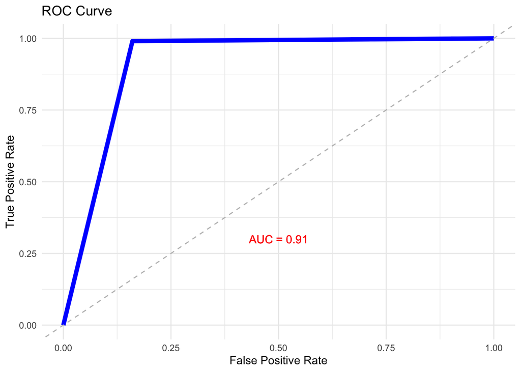

```r
## ROC Curve
roc_obj <- roc(data2$Attrition, as.numeric(predictions))
auc_value <- auc(roc_obj)
roc_data <- data.frame(1 - roc_obj$specificities, roc_obj$sensitivities)
roc_plot <- ggplot(roc_data, aes(x = 1 - roc_obj$specificities, y = roc_obj$sensitivities)) +
  geom_line(color = "blue", size = 2) +
  geom_abline(intercept = 0, slope = 1, linetype = "dashed", color = "gray") +
  labs(title = "ROC Curve", x = "False Positive Rate", y = "True Positive Rate") +
  theme_minimal()
roc_plot_with_auc <- roc_plot +
  geom_text(x = 0.5, y = 0.3, label = paste("AUC =", round(auc_value, 2)), color = "red")
print(roc_plot_with_auc)
```

[figure not shown]

```r
## VIP Plot
var_importance <- importance(model3)
var_importance <- var_importance[order(-var_importance[, 1]), , drop = FALSE]
barplot(var_importance[, 1], names.arg = rownames(var_importance), las = 2, col = "steelblue",
        main = "Mean Decrease Gini: Variable Importance Plot",
        ylab = "Mean Decrease Gini")
```

[output not shown]